# Nonlinear mixed models (NLME)

Nick Green, Kennesaw State University

December 22, 2021

# 1 Overview

**Nonlinear mixed effects models (NLME)** extend the nonlinear model (NLS) to allow parameters to vary randomly by a factor. In an LMM or GLMM, the parameters that could vary randomly were the intercept and slope (or other coefficients). Because NLS models don’t always have intercepts and slopes, the random effects can potentially apply to any parameter in the model. For example, a mixed effects Michaelis-Menten model might have an asymptote, Michaelis constant, or both that vary randomly between levels of a factor:

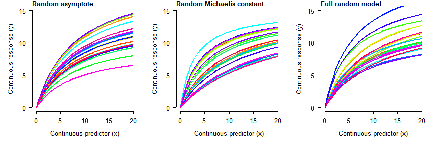

As you might expect, fitting NLME can be tricky: it combines all of the [difficulties with nonlinear models](https://greenquanteco.github.io/06-non-02-micmen.html) and of mixed models! One of the most commonly used options is the `nlmer()` function from the `lme4` package. For complicated models you may want to consider using Bayesian inference with JAGS because of the added flexibility afforded by the Markov chain Monte Carlo (MCMC) paradigm.

# 2 NLME on simulated data

Let’s simulate data that might have come from an enzyme kinetics study. We’ll model reaction rate *y* as a function of concentration *x* for some family of substrates. NLME might be a better choice than NLS for such a problem because the selection of substrates is only a sampling of the potential substrates, and the researcher is interested in how reaction rate might vary with concentration for other, untested substrates.

```r
set.seed(123)

# data structure: number of substates (nlev)
# and replicates per concentration
# and substrate (nrep)
nlev <- 8
nrep <- 3

# concentrations:
x <- 10^seq(-2, 2, by=0.5)

# hyperparameters for a and b
avec <- rnorm(nlev, 129, 12)
bvec <- rnorm(nlev, 22, 12)

# assemble dataframe of predictors and parameters
dat <- expand.grid(subs=1:nlev, conc=x, rep=1:nrep)
dat$a <- avec[dat$subs]
dat$b <- bvec[dat$subs]

# calculate expected value
dat$mu <- (dat$a*dat$conc)/(dat$b+dat$conc)

# residual SD and residuals
sigma <- 10
dat$y <- rnorm(nrow(dat), dat$mu, sigma)

# can't have negative values
dat$y <- pmax(0, dat$y)

# add colors for plotting
cols <- rainbow(nlev)
dat$col <- cols[dat$subs]
```

Make a quick plot of expected value in each group (substrate):

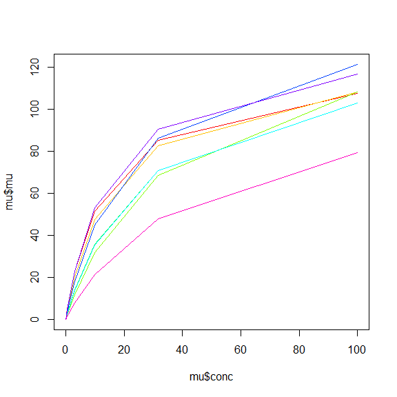

We can also see the actual data:

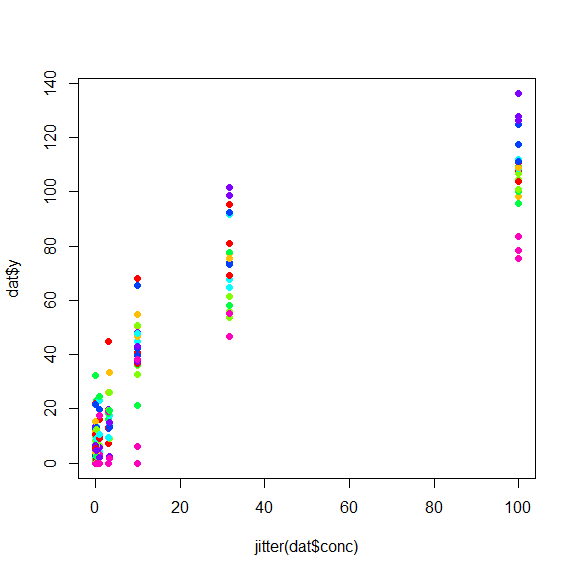

```r
plot(jitter(dat$conc), dat$y, pch=16, col=dat$col)
```

Faced with these data, we might suspect that the *y* variable (reaction rate) could be modeled by a Michaelis-Menten (MM) function. However, we might also suspect that there is a lot of variation due to substrate that is not accounted for by a garden variety MM model. If we are not interested in these substrates in particular, but only as representatives of all substrates, then a mixed model is called for. What is not clear is whether the asymptote, Michaelis constant, or both should be random. Fortunately, it is straightforward to test all three variations.

To use `nlmer()`, you need to specify the model in 3 parts: response, function, and random effects. The parts are separated by tildes (`~`). Unlike `nls()`, where the model formula can be provided directly, the model formula in `nlmer()` must be a function that takes in a predictor and uses named parameters to produce a numeric output. The self-start functions we saw in the [NLS unit](https://greenquanteco.github.io/06-non-02-micmen.html) can be used for this, but unlike in `nls()` you *always* need to provide starting values. The starting values can be estimated or guessed at by inspecting the scatterplot and thinking about the meaning of each parameter ([example](https://greenquanteco.github.io/06-non-02-micmen.html#3_Example_with_simulated_data)). Fortunately, the random effects syntax works in much the same way as it does in `lmer()`.

```r
library(lme4)

# named vector of starting values
startvec <- c(a=120, b=25)

# model 1: random asymptote
mod1 <- nlmer(y~SSmicmen(conc, a, b)~a|subs,
    data=dat, start=startvec)

# model 2: random Michaelis constant
mod2 <- nlmer(y~SSmicmen(conc, a, b)~b|subs,
    data=dat, start=startvec)

# model 3: random both parameters
mod3 <- nlmer(y~SSmicmen(conc, a, b)~(a|subs)+(b|subs),
    data=dat, start=startvec)
```

```r
AIC(mod1, mod2, mod3)
```

```
##      df      AIC
## mod1  4 1563.909
## mod2  4 1573.510
## mod3  5 1561.939
```

Unfortunately, generating predictions for `nlmer()` models is not straightforward[^1]. So, let’s use a different method of model fitting: Markov chain Monte Carlo (MCMC). You’ll need a separate program, JAGS (Plummer 2003), and the R packages rjags (Plummer 2021) and R2jags (Su and Masanao Yajima 2021). The general procedure for using JAGS is to first write the model to a text file using `sink()`, then call JAGS from within R. JAGS will then read the text file and fit the model. The code block below will write the model file to your current R working directory.

```r
# write model file
mod.name <- "nlme_mod03.txt"
```

```r
sink(mod.name)
cat("
    model{
        # priors
        ## hyperparameters
        mu.a ~ dunif(1, 200)
        sd.a ~ dunif(1, 20)
        mu.b ~ dunif(1, 200)
        sd.b ~ dunif(1, 20)

        ## precision of a and b
        tau.a <- 1/(sd.a * sd.a)
        tau.b <- 1/(sd.b * sd.b)

        ## parameters
        for(i in 1:nlev){
            a.vec[i]~dnorm(mu.a, tau.a)
            b.vec[i]~dnorm(mu.b, tau.b)
        }

        ## residual SD and precision (tau)
        sigma ~ dunif(0, 1e4)
        tau.y <- 1 / (sigma * sigma)

        # likelihood
        for(i in 1:N){
            y[i] ~ dnorm(eta[i], tau.y)
            eta[i] <- (a.vec[levs[i]] *
                x[i])/(b.vec[levs[i]]+x[i])
        }# i for N
    }#model
", fill=TRUE)
sink()
```

Next, package the data up for JAGS. Any value or set of values used in the model must be included by name in a list.

```r
# package data for JAGS
in.data <- list(y=dat$y,
                x=dat$conc,
                levs=dat$subs,
                N=nrow(dat),
                nlev=nlev
                )
```

```r
# define initial values for MCMC chains
init.fun <- function(nc){
    res <- vector("list", length=nc)
    for(i in 1:nc){
        res[[i]] <- list(
            mu.a=runif(1, 1, 200),
            sd.a=runif(1, 1, 20),
            mu.b=runif(1, 1, 200),
            sd.b=runif(1, 1, 20),
            a.vec=runif(nlev, 1, 200),
            b.vec=runif(nlev, 1, 20),
            sigma=runif(1, 0.1, 20))
    }#i
    return(res)
}
```

$$n_{post}=n_{chains}\left(\frac{n_{iter}-n_{burn}}{n_{thin}}\right)$$

Set the last few parameters and send the model to JAGS:

```r
library(rjags)
library(R2jags)

nchains <- 3
inits <- init.fun(nchains)

# parameters to monitor
params <- c("mu.a", "sd.a", "mu.b", "sd.b", "sigma",
    "a.vec", "b.vec")

# MCMC parameters
n.iter <- 5e3
n.burnin <- 1e2
n.thin <- 100

mod3j <- jags(data=in.data, inits=inits,
              parameters.to.save=params,
              model.file=mod.name,
              n.chains=nchains, n.iter=n.iter,
              n.burnin=n.burnin, n.thin=n.thin)#jags
```

[output not shown]

The most important part of the output is here obtained by printing the model object to the console:

```r
mod3j
```

```
## Inference for Bugs model at "nlme_mod03.txt", fit using jags,
##  3 chains, each with 5000 iterations (first 100 discarded), n.thin = 100
##  n.sims = 147 iterations saved
##           mu.vect sd.vect     2.5%      25%      50%      75%    97.5%  Rhat
## a.vec[1]  128.513   6.888  116.049  123.847  128.003  133.146  142.769 0.995
## a.vec[2]  124.844   7.369  112.265  119.553  123.998  129.427  141.065 1.027
## a.vec[3]  131.011   8.392  117.081  125.895  129.974  135.282  149.705 1.002
## a.vec[4]  128.561   7.784  114.009  123.471  128.797  133.397  143.299 1.018
## a.vec[5]  130.787   8.030  116.861  125.303  129.991  135.742  146.610 1.034
## a.vec[6]  141.115   7.310  128.492  136.745  139.739  145.799  157.006 1.030
## a.vec[7]  157.374   8.199  142.347  152.461  156.953  161.871  173.935 1.023
## a.vec[8]  112.327   9.903   94.144  105.211  111.992  118.570  132.351 0.999
## b.vec[1]   17.655   3.048   12.552   15.310   17.434   19.692   23.174 0.998
## b.vec[2]   17.503   3.452   12.110   14.843   17.549   19.415   24.899 1.045
## b.vec[3]   30.481   5.581   21.453   27.065   29.868   33.323   43.953 1.004
## b.vec[4]   25.801   4.611   18.427   22.587   25.446   28.601   35.398 0.993
## b.vec[5]   22.084   3.786   15.758   19.649   21.693   24.311   29.921 1.026
## b.vec[6]   22.279   3.304   17.169   19.847   21.889   24.332   29.111 1.015
## b.vec[7]   23.264   3.522   17.293   20.870   22.635   25.248   30.658 1.036
## b.vec[8]   38.488   8.071   25.234   32.215   37.642   44.289   55.795 1.007
## mu.a      131.686   5.700  120.606  128.297  131.977  135.282  143.156 0.999
## mu.b       24.845   3.978   18.438   22.266   24.084   27.565   32.609 1.018
## sd.a       14.226   3.392    7.310   11.971   14.170   16.999   19.760 1.064
## sd.b        9.087   3.613    3.604    6.349    8.695   11.196   17.040 1.037
## sigma       8.244   0.411    7.515    7.919    8.222    8.496    9.086 1.017
## deviance 1523.397   6.499 1513.634 1518.874 1522.689 1526.226 1537.916 1.080
##          n.eff
## a.vec[1]   150
## a.vec[2]    75
## a.vec[3]   150
## a.vec[4]   150
## a.vec[5]    68
## a.vec[6]   150
## a.vec[7]   140
## a.vec[8]   150
## b.vec[1]   150
## b.vec[2]    58
## b.vec[3]   150
## b.vec[4]   150
## b.vec[5]    67
## b.vec[6]   140
## b.vec[7]    76
## b.vec[8]   120
## mu.a       150
## mu.b       150
## sd.a        83
## sd.b        75
## sigma      150
## deviance    35
##
## For each parameter, n.eff is a crude measure of effective sample size,
## and Rhat is the potential scale reduction factor (at convergence, Rhat=1).
##
## DIC info (using the rule, pD = var(deviance)/2)
## pD = 20.2 and DIC = 1543.5
## DIC is an estimate of expected predictive error (lower deviance is better).
```

Unlike `lmer()`, `glmer()`, and `nlmer()`, an MCMC output automatically contains estimates of the region in which value of each parameter is likely to fall. However, instead of being called “confidence intervals” (CI), these intervals are called **credible intervals (CRI)**. The difference between a CI and a CRI is in how they are calculated. CI are calculated using the estimated mean, SE, and properties of the normal distribution. CRI, on the other hand, are simply quantiles of the posterior distribution of the parameter. This means that CRI are inherently Bayesian and only defined in Bayesian inference; CI are frequentist and used in non-Bayesian context. CRI have the distinct advantage of not assuming anything about the appropriate distribution for the parameter.

Other outputs of MCMC can be used to calculate model predictions and their 95% CRI. Let’s use the posterior draws to calculate model predictions. The posteriors are stored in several ways within the JAGS output. For generating predictions and CRI, we should use the values in the `sims.matrix` part of the output, which have already been permuted (this reduces bias in the predictions).

```r
po <- mod3j$BUGSoutput$sims.matrix
nsim <- nrow(po)
a.cols <- grep("a.vec", colnames(po))
b.cols <- grep("b.vec", colnames(po))

pn <- 100
x <- seq(min(dat$conc), max(dat$conc), length=pn)

# version 1: full random effects
dx1 <- expand.grid(subs=1:nlev, conc=x)
dy1 <- matrix(NA, nrow=nrow(dx1), ncol=nsim)
for(i in 1:nrow(dx1)){
    ilev <- dx1$subs[i]
    use.ac <- a.cols[ilev]
    use.bc <- b.cols[ilev]
    for(j in 1:nsim){
        use.a <- po[j, use.ac]
        use.b <- po[j, use.bc]
        dy1[i,j] <- (use.a*dx1$conc[i])/(use.b+dx1$conc[i])
    }
}
dx1$lo <- apply(dy1, 1, quantile, 0.025)
dx1$mn <- apply(dy1, 1, quantile, 0.5)
dx1$up <- apply(dy1, 1, quantile, 0.975)


# version 2: no random effects
dx2 <- data.frame(conc=x)
dy2 <- matrix(NA, nrow=nrow(dx2), ncol=nrow(po))
for(i in 1:nrow(dx2)){
    for(j in 1:nsim){
        dy2[i,j] <- po[j,"mu.a"]*dx2$conc[i]/(po[j,"mu.b"]+dx2$conc[i])
    }
}
dx2$lo <- apply(dy2, 1, quantile, 0.025)
dx2$mn <- apply(dy2, 1, quantile, 0.5)
dx2$up <- apply(dy2, 1, quantile, 0.975)
```

Now make the plot:

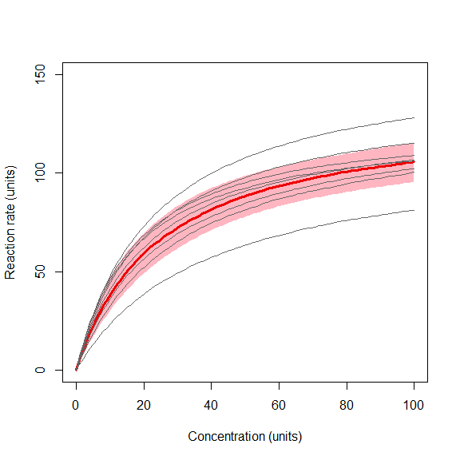

```r
plot(dx2$conc, dx2$mn, type="n",
    xlab="Concentration (units)",
    ylab="Reaction rate (units)",
    ylim=c(0, 150))
polygon(x=c(dx2$conc, rev(dx2$conc)),
    y=c(dx2$lo, rev(dx2$up)),
    border=NA, col="lightpink")
points(dx2$conc, dx2$mn, type="l", lwd=3, col="red2")
for(i in 1:nlev){
    flag <- which(dx1$subs==i)
    points(dx1$conc[flag], dx1$mn[flag],
        type="l", col="grey40")
}
```

The plot shows the curves for individual substrates as thin lines, and the overall prediction with 95% CRI as a red line and shaded area. The highlighted curve and CRI is the expectation for any level of the random effect factor not in the original dataset. In other words, it is what the model predicts given the variability in the levels of the random factor that have already been observed. The ability to make robust predictions about unobserved levels of the random factor is one of the biggest advantages of mixed models.

# 3 NLME on real data

Kirchman et al. (2009) investigated the role of temperature and organic carbon availability on growth and secondary production by heterotrophic bacteria in the oceans. Heterotrophic bacteria are key components of marine food webs and can exert enormous control over ecosystem cycling of nutrients. The figure below shows the place of heterotrophic bacteria in the marine “microbial loop” that relates dissolved CO2 and dissolved organic carbon (DOC) (Kirchman et al. 2009).

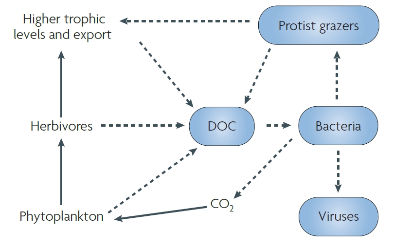

To better understand how these bacteria affect ocean ecosystems, the authors examined bacterial growth (d<sup>-1</sup>) and productivity (mmol C m<sup>-2</sup> d<sup>-1</sup>) varied with latitude ($^\circ$N or $^\circ$S), nutrient availability ($\mu$M C), and mean annual temperature ($^\circ$C). We will re-examine part of their dataset to practice using nonlinear mixed effects models. The data are stored in this [text file](https://greenquanteco.github.io/kirchman_data_2021-10-21.csv). Download this file and save it to your R working directory.

```r
in.name <- "kirchman_data_2021-10-21.csv"
dat <- read.csv(in.name, header=TRUE)
```

As usual, we start by exploring the distributions of the variables and a basic scatterplot.

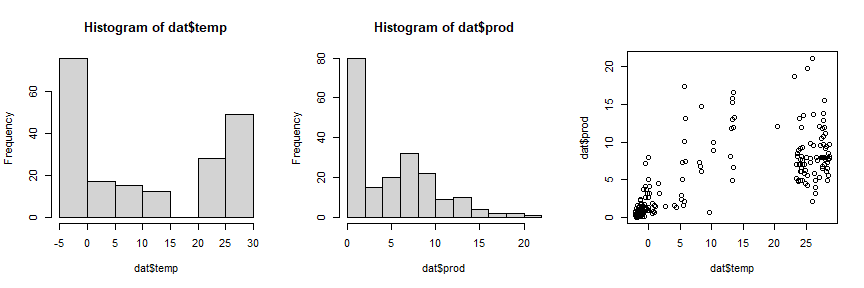

```r
par(mfrow=c(1,3))
hist(dat$temp)
hist(dat$prod)
plot(dat$temp, dat$prod)
```

Make a log-transformed version of productivity and a new set of exploratory figures. We’ll use $log_{10}$ to save ourselves some trouble later.

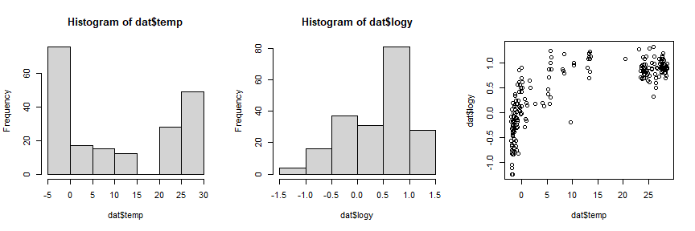

```r
dat$logy <- log10(dat$prod)

par(mfrow=c(1,3))
hist(dat$temp)
hist(dat$logy)
plot(dat$temp, dat$logy)
```

There seem to be some distinct clumps in the scatterplot which might correspond to the grouping variable sea. Let’s add some colors to the dataset and then to the plot. Just for fun, let’s make a color ramp from colder to warmer sites.

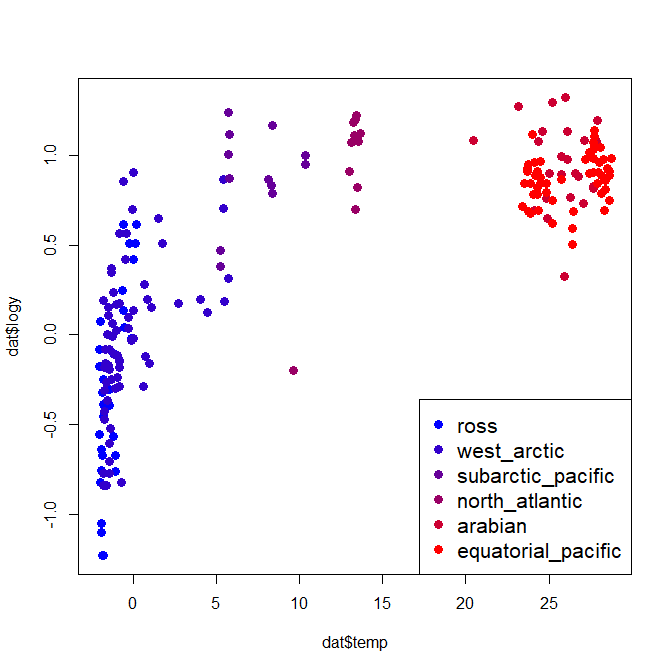

```r
agg <- aggregate(temp~sea, data=dat, median)
agg <- agg[order(agg$temp),]
nsea <- nrow(agg)
seas <- agg$sea

# color ramp from colder (blue) to warmer (red)
col.fun <- colorRampPalette(c("blue", "red"))
cols <- col.fun(nsea)
agg$col <- cols

matchx <- match(dat$sea, agg$sea)
dat$col <- agg$col[matchx]

par(mfrow=c(1,1))
plot(dat$temp, dat$logy,
    pch=16, col=dat$col, cex=1.3)
legend("bottomright", legend=seas,
    pch=16, col=cols, cex=1.3)
```

As nice as the color ramp effect is, the seas are still hard to tell apart. Let’s add some shapes as well.

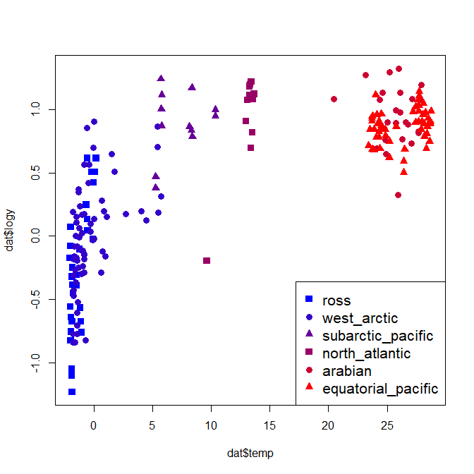

```r
agg$shp <- 15:17
dat$shp <- agg$shp[matchx]

par(mfrow=c(1,1))
plot(dat$temp, dat$logy,
    pch=dat$shp, col=dat$col, cex=1.3)
legend("bottomright", legend=seas,
    pch=agg$shp, col=cols, cex=1.3)
```

There appears to be an effect of temperature and possibly of sea. Biologically, the bacteria within a sea are probably more similar to each other than they are to bacteria in other seas. So, we should expect there to be some effect of sea just based on genetic relatedness or some other kind of similarity. However, we want a model that is applicable to all seas, not just the 6 in this dataset. For example, this dataset is missing the Indian Ocean, the Mediterranean, the Caribbean, the Sea of Japan, and many others. So, we need a nonlinear *mixed model*. We don’t know exactly what curve to use, so we’ll try a few. The table below shows the equations for each model.

| Model | Function | Fixed effects | Random effects |
| --- | --- | --- | --- |
| 1 | Monod, random *a* | $\mu_i=\frac{a_jx_i}{b+x_i}$ | $a_j \sim Normal\left(\mu_a,\sigma_a^2\right)$ |
| 2 | Monod, random *b* | $\mu_i=\frac{ax_i}{b_j+x_i}$ | $b_j \sim Normal\left(\mu_b,\sigma_b^2\right)$ |
| 3 | Monod, random *a* and *b* | $\mu_i=\frac{a_jx_i}{b_j+x_i}$ | $a_j \sim Normal\left(\mu_a,\sigma_a^2\right)$ |
|  |  |  | $b_j \sim Normal\left(\mu_b,\sigma_b^2\right)$ |
| 4 | Holling type III, random *a* | $\mu_i=\frac{a_jx_i^2}{b^2+x_i^2}$ | $a_j \sim Normal\left(\mu_a,\sigma_a^2\right)$ |
| 5 | Holling type III, random *b* | $\mu_i=\frac{ax_i^2}{b_j^2+x_i^2}$ | $b_j \sim Normal\left(\mu_b,\sigma_b^2\right)$ |
| 6 | Holling type III, random *a* and *b* | $\mu_i=\frac{a_jx_i^2}{b^2+x_i^2}$ | $a_j \sim Normal\left(\mu_a,\sigma_a^2\right)$ |
|  |  |  | $b_j \sim Normal\left(\mu_b,\sigma_b^2\right)$ |
| 7 | Monomolecular, random *a* | $\mu_i=a_j\left(1-e^{-bx}\right)$ | $a_j \sim Normal\left(\mu_a,\sigma_a^2\right)$ |
| 8 | Monomolecular, random *b* | $\mu_i=a\left(1-e^{-b_jx}\right)$ | $b_j \sim Normal\left(\mu_b,\sigma_b^2\right)$ |
| 9 | Monomolecular, random *a* and *b* | $\mu_i=a_j\left(1-e^{-b_jx}\right)$ | $a_j \sim Normal\left(\mu_a,\sigma_a^2\right)$ |
|  |  |  | $b_j \sim Normal\left(\mu_b,\sigma_b^2\right)$ |

Fitting the **Monod (aka: Michaelis-Menten)** model with mixed effects is simple, because there is a self-start version of the function designed for nonlinear modeling (we’ve used it before). We just need to remember to supply reasonable starting values.

```r
library(lme4)
# Monod (aka: Michaelis-Menten) with
# different random structures
startvec <- c(a=1.3, b=1)
mod01 <- nlmer(logy~SSmicmen(temp, a, b)~a|sea,
    data=dat, start=startvec)
mod02 <- nlmer(logy~SSmicmen(temp, a, b)~b|sea,
    data=dat, start=startvec)
mod03 <- nlmer(logy~SSmicmen(temp, a, b)~(a|sea)+(b|sea),
    data=dat, start=startvec)
```

The other two curves are less simple to fit because there is no self-start model available. In `nlmer()`, the fixed part of the model needs to be provided as a special type of function that takes in input values and parameter values, and outputs a vector of response values. Additionally, the function needs to have some internal attributes that let `nlmer()` evaluate its likelihood function and how the likelihood function changes. The procedure below seems to work well.

```r
# Holling type III (Bolker 2008 p. 92)
startvec <- c(a=1.3, b=1)

# define model as function
holl <- ~(a*x^2)/(b^2 + x^2)

# prepare version of function for nlmer()
hollfun <- deriv(holl, namevec=c("a", "b"),
    function.arg=c("x", "a", "b"))

# fit models
mod04 <- nlmer(logy~hollfun(temp, a, b)~a|sea,
    data=dat, start=startvec)
mod05 <- nlmer(logy~hollfun(temp, a, b)~b|sea,
    data=dat, start=startvec)
```

```
## Error in fn(nM$xeval()): prss{Update} failed to converge in 'maxit' iterations
```

```r
mod06 <- nlmer(logy~hollfun(temp, a, b)~(a|sea)+(b|sea),
    data=dat, start=startvec)
```

```
## Error in fn(nM$xeval()): prss{Update} failed to converge in 'maxit' iterations
```

```r
# monomolecular (Bolker p. 95)
# special case of von Bertalanffy curve

# define model as function
mono <- ~a*(1-exp(-b*x))

# prepare version of function for nlmer()
monofun <- deriv(mono, namevec=c("a", "b"),
    function.arg=c("x", "a", "b"))

mod07 <- nlmer(logy~monofun(temp, a, b)~a|sea,
    data=dat, start=startvec)
mod08 <- nlmer(logy~monofun(temp, a, b)~b|sea,
    data=dat, start=startvec)
mod09 <- nlmer(logy~monofun(temp, a, b)~(a|sea)+(b|sea),
    data=dat, start=startvec)
```

R was not able to find solutions for models 5 and 6, so we can discard those. Let’s examine the outputs of the models that did fit. First, we can use AIC to get a sense of which models might worked best:

```r
aic.df <- AIC(mod01, mod02, mod03, mod04, mod07, mod08, mod09)
aic.df$delta <- aic.df$AIC - min(aic.df$AIC)
aic.df$wt <- exp(-0.5*aic.df$delta)
aic.df$wt <- aic.df$wt/sum(aic.df$wt)
aic.df <- aic.df[order(-aic.df$wt),]
aic.df
```

```
##       df      AIC      delta           wt
## mod08  4 105.4030   0.000000 6.545609e-01
## mod09  5 107.4030   1.999977 2.408023e-01
## mod07  4 109.0699   3.666938 1.046368e-01
## mod04  4 156.6238  51.220848 4.937240e-12
## mod01  4 164.5428  59.139802 9.416842e-14
## mod03  5 166.5428  61.139802 3.464263e-14
## mod02  4 376.3158 270.912825 9.726972e-60
```

The AICs suggest that model 8 is the best-fitting. This was the monomolecular curve with the growth constant (*b*) varying by sea. The Monod functions were the worst fitting (by AIC); and the only Holling curve that fit was somewhere in the middle. Let’s generate and plot model predictions as usual. We’ll have to calculate the predictions manually because the `predict()` method for `nlmer()` objects is not well documented.

```r
# number of points and x values
pn <- 50
px <- seq(min(dat$temp), max(dat$temp), length=pn)

# predictions by level (sea)
dx1 <- expand.grid(sea=seas, temp=px)
dx1 <- dx1[order(dx1$sea, dx1$temp),]

## coefficients table (including random b)
cofs <- coef(mod08)$sea
matchx <- match(dx1$sea, rownames(cofs))
dx1$a <- cofs$a[matchx]
dx1$b <- cofs$b[matchx]

## calculate predictions
dx1$y <- dx1$a*(1-exp(-dx1$b*dx1$temp))

# prediction of overall mean (applicable to other seas)
dx2 <- data.frame(temp=px)
fixe <- fixef(mod08)
dx2$y <- fixe["a"]*(1-exp(-fixe["b"]*dx2$temp))
```

Now we can assemble a few pieces and make our nice plot.

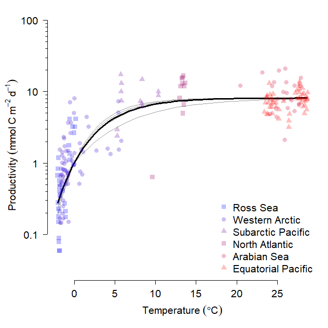

```r
# 40% opacity (alpha) to the colors for
# clearer plot (pun intended)
dat$col2 <- paste0(dat$col, "40")

# nicer version of names for legend
leg.labs <- c(
    "Ross Sea", "Western Arctic",
    "Subarctic Pacific", "North Atlantic",
    "Arabian Sea", "Equatorial Pacific")

# graphical parameters for attractive plot
par(mfrow=c(1,1), mar=c(5.1, 5.1, 1.1, 1.1),
    lend=1, las=1, bty="n",
    cex.axis=1.3, cex.lab=1.3)
# set up plot area
## note expression() used for proper axis labels
## and y axis suppressed (yaxt="n") so a better
## y axis can be added manually
plot(dat$temp, dat$logy, type="n",
    xlab=expression(Temperature~(degree*C)),
    ylab=expression(Productivity~(mmol~C~m^{-2}~d^{-1})),
    yaxt="n",
    ylim=c(-1.5, 2))

# add sea-specific lines in a loop
for(i in 1:nsea){
    flag <- which(dx1$sea == seas[i])
    points(dx1$temp[flag], dx1$y[flag],
        type="l", col="grey60")
}

# add fixed effect line
points(dx2$temp, dx2$y, type="l", lwd=3)

# original data, with semi-transparent colors
points(dat$temp, dat$logy,
    pch=dat$shp, col=dat$col2, cex=1.3)

# fancy y axis with logarithmic tick marks
axis(side=2, at=seq(-1, 2, by=1),
    labels=c(0.1, 1, 10, 100))
axis(side=2, at=log10(c(2:9/10, 2:9, 2:9*10)),
    labels=NA, tcl=-0.25)

# legend
legend("bottomright", legend=leg.labs, pch=agg$shp,
    col=paste0(cols, "40"), cex=1.3, bty="n")
```

[**Go back to main page**](https://greenquanteco.github.io/index.html)

# 4 References

Kirchman, D. L., X. A. G. Morán, and H. Ducklow. 2009. Microbial growth in the polar oceans—role of temperature and potential impact of climate change. Nature Reviews Microbiology 7:451–459.

Plummer, M. 2003. JAGS: A program for analysis of Bayesian graphical models using Gibbs sampling. Pages 1–10 Proceedings of the 3rd international workshop on distributed statistical computing. Vienna, Austria.

Plummer, M. 2021. [rjags: Bayesian graphical models using MCMC](https://CRAN.R-project.org/package=rjags).

Su, Y.-S., and Masanao Yajima. 2021. [R2jags: Using R to run ’JAGS’](https://CRAN.R-project.org/package=R2jags).

# 5 Legal notice

This site is for educational purposes only. This work and its content is released under the [Creative Commons Attribution-ShareAlike 4.0](https://creativecommons.org/licenses/by-sa/4.0/) license. Inclusion of third-party data falls under guidelines of fair use as defined in [section 107 of the US Copyright Act of 1976](https://www.law.cornell.edu/uscode/text/17/107).

[^1]: I couldn’t get it to work at all.
[^2]: OpenBUGS and WinBUGS are two alternative programs that R can call to conduct MCMC sampling. WinBUGS is older and closed-source; OpenBUGS is newer and open-source. The modeling languages of JAGS, WinBUGS, and OpenBUGS are mostly identical. I learned Bayesian modeling with WinBUGS, but since 2020 have switched to JAGS. In my experience, JAGS is faster and more stable, while OpenBUGS is slower and less stable. Both are far preferable to WinBUGS